# Hurricane and Typhoon Data Analysis (1851–2014)

Data cleaning is a critical step in any data analysis process. In this project, we:

- Identified and handled missing values
- Checked for inconsistencies in the dataset
- Prepared the data for analysis by ensuring correct formats and structures

These steps improve data quality and ensure more reliable results in the analysis.

```python
data_clean = data.replace(-999, np.nan) # Padronizing: my missing values are: -999 -> Replacing them to NaN
data_clean
```

|  | ID | Name | Date | Time | Event | Status | Latitude | Longitude | Maximum Wind | Minimum Pressure | ... | Low Wind SW | Low Wind NW | Moderate Wind NE | Moderate Wind SE | Moderate Wind SW | Moderate Wind NW | High Wind NE | High Wind SE | High Wind SW | High Wind NW |
| --- | --- | --- | --- | --- | --- | --- | --- | --- | --- | --- | --- | --- | --- | --- | --- | --- | --- | --- | --- | --- | --- |
| 0 | AL011851 | UNNAMED | 18510625 | 0 |  | HU | 28.0N | 94.8W | 80 | NaN | ... | NaN | NaN | NaN | NaN | NaN | NaN | NaN | NaN | NaN | NaN |
| 1 | AL011851 | UNNAMED | 18510625 | 600 |  | HU | 28.0N | 95.4W | 80 | NaN | ... | NaN | NaN | NaN | NaN | NaN | NaN | NaN | NaN | NaN | NaN |
| 2 | AL011851 | UNNAMED | 18510625 | 1200 |  | HU | 28.0N | 96.0W | 80 | NaN | ... | NaN | NaN | NaN | NaN | NaN | NaN | NaN | NaN | NaN | NaN |
| 3 | AL011851 | UNNAMED | 18510625 | 1800 |  | HU | 28.1N | 96.5W | 80 | NaN | ... | NaN | NaN | NaN | NaN | NaN | NaN | NaN | NaN | NaN | NaN |
| 4 | AL011851 | UNNAMED | 18510625 | 2100 | L | HU | 28.2N | 96.8W | 80 | NaN | ... | NaN | NaN | NaN | NaN | NaN | NaN | NaN | NaN | NaN | NaN |
| ... | ... | ... | ... | ... | ... | ... | ... | ... | ... | ... | ... | ... | ... | ... | ... | ... | ... | ... | ... | ... | ... |
| 49100 | AL122015 | KATE | 20151112 | 1200 |  | EX | 41.3N | 50.4W | 55 | 981.0 | ... | 180.0 | 120.0 | 120.0 | 120.0 | 60.0 | 0.0 | 0.0 | 0.0 | 0.0 | 0.0 |
| 49101 | AL122015 | KATE | 20151112 | 1800 |  | EX | 41.9N | 49.9W | 55 | 983.0 | ... | 180.0 | 120.0 | 120.0 | 120.0 | 60.0 | 0.0 | 0.0 | 0.0 | 0.0 | 0.0 |
| 49102 | AL122015 | KATE | 20151113 | 0 |  | EX | 41.5N | 49.2W | 50 | 985.0 | ... | 200.0 | 220.0 | 120.0 | 120.0 | 60.0 | 0.0 | 0.0 | 0.0 | 0.0 | 0.0 |
| 49103 | AL122015 | KATE | 20151113 | 600 |  | EX | 40.8N | 47.5W | 45 | 985.0 | ... | 180.0 | 220.0 | 0.0 | 0.0 | 0.0 | 0.0 | 0.0 | 0.0 | 0.0 | 0.0 |
| 49104 | AL122015 | KATE | 20151113 | 1200 |  | EX | 40.7N | 45.4W | 45 | 987.0 | ... | 150.0 | 220.0 | 0.0 | 0.0 | 0.0 | 0.0 | 0.0 | 0.0 | 0.0 | 0.0 |

49105 rows × 22 columns

```python
data_clean.isna()
```

|  | ID | Name | Date | Time | Event | Status | Latitude | Longitude | Maximum Wind | Minimum Pressure | ... | Low Wind SW | Low Wind NW | Moderate Wind NE | Moderate Wind SE | Moderate Wind SW | Moderate Wind NW | High Wind NE | High Wind SE | High Wind SW | High Wind NW |
| --- | --- | --- | --- | --- | --- | --- | --- | --- | --- | --- | --- | --- | --- | --- | --- | --- | --- | --- | --- | --- | --- |
| 0 | False | False | False | False | False | False | False | False | False | True | ... | True | True | True | True | True | True | True | True | True | True |
| 1 | False | False | False | False | False | False | False | False | False | True | ... | True | True | True | True | True | True | True | True | True | True |
| 2 | False | False | False | False | False | False | False | False | False | True | ... | True | True | True | True | True | True | True | True | True | True |
| 3 | False | False | False | False | False | False | False | False | False | True | ... | True | True | True | True | True | True | True | True | True | True |
| 4 | False | False | False | False | False | False | False | False | False | True | ... | True | True | True | True | True | True | True | True | True | True |
| ... | ... | ... | ... | ... | ... | ... | ... | ... | ... | ... | ... | ... | ... | ... | ... | ... | ... | ... | ... | ... | ... |
| 49100 | False | False | False | False | False | False | False | False | False | False | ... | False | False | False | False | False | False | False | False | False | False |
| 49101 | False | False | False | False | False | False | False | False | False | False | ... | False | False | False | False | False | False | False | False | False | False |
| 49102 | False | False | False | False | False | False | False | False | False | False | ... | False | False | False | False | False | False | False | False | False | False |
| 49103 | False | False | False | False | False | False | False | False | False | False | ... | False | False | False | False | False | False | False | False | False | False |
| 49104 | False | False | False | False | False | False | False | False | False | False | ... | False | False | False | False | False | False | False | False | False | False |

49105 rows × 22 columns

```python
# Counting total of duplicates rows
total_duplicatas = data_clean.duplicated().sum()
print(f"Número total de linhas duplicadas: {total_duplicatas}")
```

```
Número total de linhas duplicadas: 0
```

```python
# Checking missing values
print("\n--- Missing Values (NaN) per column after padronized ---")
print(data_clean.isna().sum())
```

```
--- Missing Values (NaN) per column after padronized ---
ID                      0
Name                    0
Date                    0
Time                    0
Event                   0
Status                  0
Latitude                0
Longitude               0
Maximum Wind            0
Minimum Pressure    30669
Low Wind NE         43184
Low Wind SE         43184
Low Wind SW         43184
Low Wind NW         43184
Moderate Wind NE    43184
Moderate Wind SE    43184
Moderate Wind SW    43184
Moderate Wind NW    43184
High Wind NE        43184
High Wind SE        43184
High Wind SW        43184
High Wind NW        43184
dtype: int64
```

```python
datacleaned = data_clean.dropna(axis = "rows", how = "any")
datacleaned
```

|  | ID | Name | Date | Time | Event | Status | Latitude | Longitude | Maximum Wind | Minimum Pressure | ... | Low Wind SW | Low Wind NW | Moderate Wind NE | Moderate Wind SE | Moderate Wind SW | Moderate Wind NW | High Wind NE | High Wind SE | High Wind SW | High Wind NW |
| --- | --- | --- | --- | --- | --- | --- | --- | --- | --- | --- | --- | --- | --- | --- | --- | --- | --- | --- | --- | --- | --- |
| 43104 | AL012004 | ALEX | 20040731 | 1800 |  | TD | 30.3N | 78.3W | 25 | 1010.0 | ... | 0.0 | 0.0 | 0.0 | 0.0 | 0.0 | 0.0 | 0.0 | 0.0 | 0.0 | 0.0 |
| 43105 | AL012004 | ALEX | 20040801 | 0 |  | TD | 31.0N | 78.8W | 25 | 1009.0 | ... | 0.0 | 0.0 | 0.0 | 0.0 | 0.0 | 0.0 | 0.0 | 0.0 | 0.0 | 0.0 |
| 43106 | AL012004 | ALEX | 20040801 | 600 |  | TD | 31.5N | 79.0W | 25 | 1009.0 | ... | 0.0 | 0.0 | 0.0 | 0.0 | 0.0 | 0.0 | 0.0 | 0.0 | 0.0 | 0.0 |
| 43107 | AL012004 | ALEX | 20040801 | 1200 |  | TD | 31.6N | 79.1W | 30 | 1009.0 | ... | 0.0 | 0.0 | 0.0 | 0.0 | 0.0 | 0.0 | 0.0 | 0.0 | 0.0 | 0.0 |
| 43108 | AL012004 | ALEX | 20040801 | 1800 |  | TS | 31.6N | 79.2W | 35 | 1009.0 | ... | 50.0 | 0.0 | 0.0 | 0.0 | 0.0 | 0.0 | 0.0 | 0.0 | 0.0 | 0.0 |
| ... | ... | ... | ... | ... | ... | ... | ... | ... | ... | ... | ... | ... | ... | ... | ... | ... | ... | ... | ... | ... | ... |
| 49100 | AL122015 | KATE | 20151112 | 1200 |  | EX | 41.3N | 50.4W | 55 | 981.0 | ... | 180.0 | 120.0 | 120.0 | 120.0 | 60.0 | 0.0 | 0.0 | 0.0 | 0.0 | 0.0 |
| 49101 | AL122015 | KATE | 20151112 | 1800 |  | EX | 41.9N | 49.9W | 55 | 983.0 | ... | 180.0 | 120.0 | 120.0 | 120.0 | 60.0 | 0.0 | 0.0 | 0.0 | 0.0 | 0.0 |
| 49102 | AL122015 | KATE | 20151113 | 0 |  | EX | 41.5N | 49.2W | 50 | 985.0 | ... | 200.0 | 220.0 | 120.0 | 120.0 | 60.0 | 0.0 | 0.0 | 0.0 | 0.0 | 0.0 |
| 49103 | AL122015 | KATE | 20151113 | 600 |  | EX | 40.8N | 47.5W | 45 | 985.0 | ... | 180.0 | 220.0 | 0.0 | 0.0 | 0.0 | 0.0 | 0.0 | 0.0 | 0.0 | 0.0 |
| 49104 | AL122015 | KATE | 20151113 | 1200 |  | EX | 40.7N | 45.4W | 45 | 987.0 | ... | 150.0 | 220.0 | 0.0 | 0.0 | 0.0 | 0.0 | 0.0 | 0.0 | 0.0 | 0.0 |

5921 rows × 22 columns

```python
# Checking missing values after cleaned
print("\n--- Missing Values (NaN) per column after cleaned ---")
print(datacleaned.isna().sum())
```

```
--- Missing Values (NaN) per column after cleaned ---
ID                  0
Name                0
Date                0
Time                0
Event               0
Status              0
Latitude            0
Longitude           0
Maximum Wind        0
Minimum Pressure    0
Low Wind NE         0
Low Wind SE         0
Low Wind SW         0
Low Wind NW         0
Moderate Wind NE    0
Moderate Wind SE    0
Moderate Wind SW    0
Moderate Wind NW    0
High Wind NE        0
High Wind SE        0
High Wind SW        0
High Wind NW        0
dtype: int64
```

4. Exploratory Data Analysis

Exploratory Data Analysis (EDA) was performed to uncover patterns and relationships within the dataset.

The analysis focused on:

- Distribution of key variables such as wind speed and pressure
- Identification of extreme values and anomalies
- Initial exploration of relationships between atmospheric variables

This step provides a deeper understanding of how cyclone characteristics evolve.

```python
variables = datacleaned [['Maximum Wind','Minimum Pressure','Low Wind NE','Low Wind SE','Moderate Wind NE','High Wind NE','High Wind SW']]
variables
```

|  | Maximum Wind | Minimum Pressure | Low Wind NE | Low Wind SE | Moderate Wind NE | High Wind NE | High Wind SW |
| --- | --- | --- | --- | --- | --- | --- | --- |
| 43104 | 25 | 1010.0 | 0.0 | 0.0 | 0.0 | 0.0 | 0.0 |
| 43105 | 25 | 1009.0 | 0.0 | 0.0 | 0.0 | 0.0 | 0.0 |
| 43106 | 25 | 1009.0 | 0.0 | 0.0 | 0.0 | 0.0 | 0.0 |
| 43107 | 30 | 1009.0 | 0.0 | 0.0 | 0.0 | 0.0 | 0.0 |
| 43108 | 35 | 1009.0 | 0.0 | 50.0 | 0.0 | 0.0 | 0.0 |
| ... | ... | ... | ... | ... | ... | ... | ... |
| 49100 | 55 | 981.0 | 220.0 | 220.0 | 120.0 | 0.0 | 0.0 |
| 49101 | 55 | 983.0 | 220.0 | 220.0 | 120.0 | 0.0 | 0.0 |
| 49102 | 50 | 985.0 | 540.0 | 520.0 | 120.0 | 0.0 | 0.0 |
| 49103 | 45 | 985.0 | 620.0 | 460.0 | 0.0 | 0.0 | 0.0 |
| 49104 | 45 | 987.0 | 710.0 | 400.0 | 0.0 | 0.0 | 0.0 |

5921 rows × 7 columns

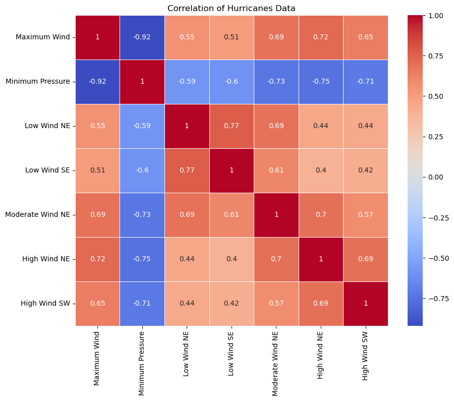

```python
# Visualisation of variables of interest using a HeatMap
correlation = variables.corr()
plt.figure (figsize=(10,8))
sns.heatmap (correlation, annot=True, cmap= "coolwarm", linewidth = 0.5)
plt.title ("Correlation of Hurricanes Data")
plt.show()
```

##### Heat Map Description

The heat map shows the correlation between several numerical variables in the hurricane dataset, such as Maximum Wind, Minimum Pressure, and the different winds in each direction (Light, Moderate, and Strong Winds).

It is clear that Maximum Wind has a strong negative correlation with Minimum Pressure. This means that as wind speed increases, the hurricane's central pressure tends to decrease, which makes sense physically.

6. Plotting boxplots to identify whether we have outliers

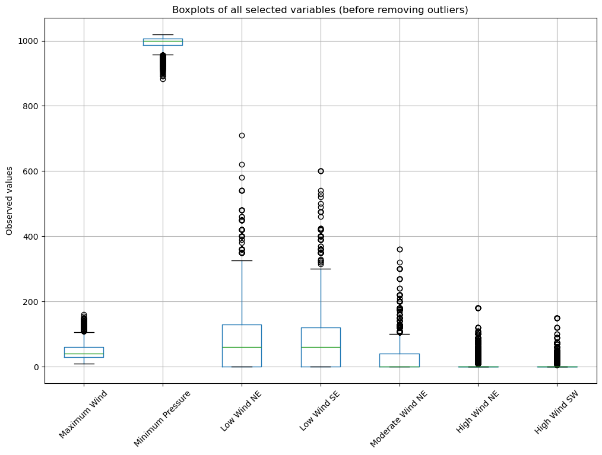

```python
# Boxplot basic for all number columns
plt.figure(figsize=(12, 8))
variables.boxplot()
plt.title("Boxplots of all selected variables (before removing outliers)")
plt.xticks(rotation=45)
plt.ylabel("Observed values")
plt.grid(True)
plt.show()
```

#### Boxplot Interpretation (Before Removing Outliers)

The boxplots above show the distribution of several numerical variables from the hurricane dataset before any outliers were removed. Each box represents the middle 50% of the data, with the horizontal line showing the median value, while the circles represent extreme values outside the normal range.

This graph shows that the dataset contains a large number of extreme values and confirms the need for an outlier removal method to make the data more consistent.

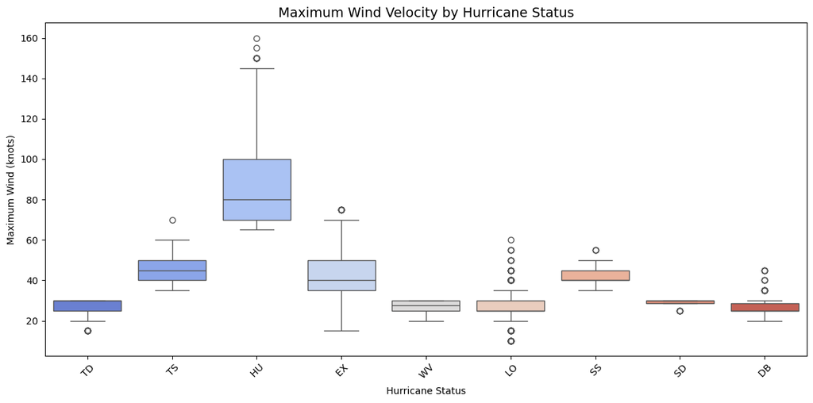

```python
# Comparing the numbers by category: Hurricane Status
plt.figure(figsize=(12,6))
sns.boxplot(x='Status', y='Maximum Wind', data=datacleaned, hue='Status', palette='coolwarm')
plt.title("Maximum Wind Velocity by Hurricane Status", fontsize=14)
plt.xlabel('Hurricane Status')
plt.ylabel('Maximum Wind (knots)')
plt.xticks(rotation=45)
plt.tight_layout()
plt.show()
```

#### Boxplot Interpretation

The boxplots show that wind intensity changes clearly between the different hurricane categories. We can see that Maximum Wind values increase from tropical depressions (TD) to tropical storms (TS) and then to hurricanes (HU). Hurricanes have a much higher median wind speed, which makes sense since they are stronger systems.

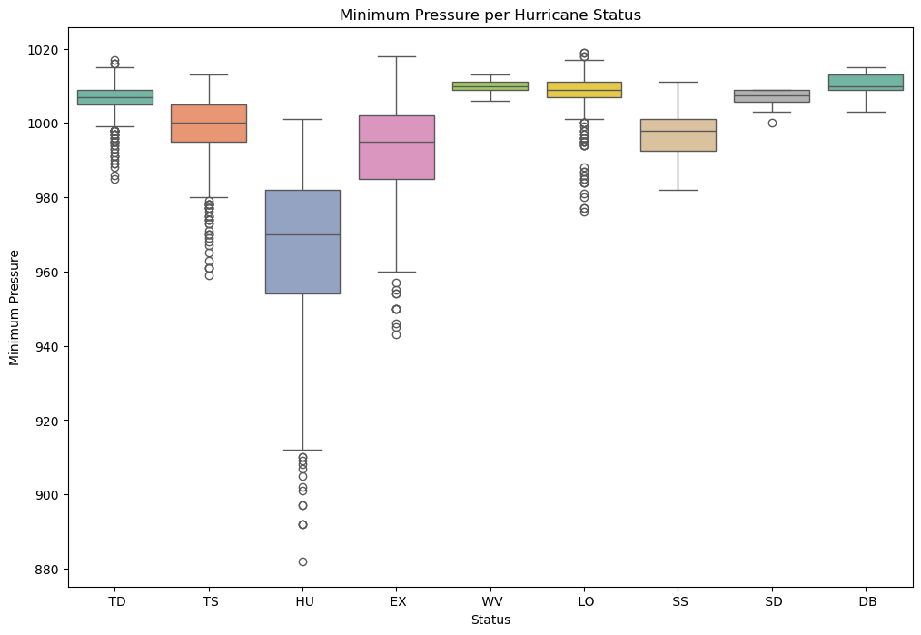

```python
# Comparing the numbers by category: Hurricane Status
plt.figure(figsize=(12,8))
sns.boxplot(x='Status', y='Minimum Pressure', data=datacleaned, hue='Status', palette='Set2')
plt.title("Minimum Pressure per Hurricane Status")
plt.show()
```

```python
# Creating a binary variable (like true/false, 0/1)
# 0 = low wind, 1 = high wind

binarydata = datacleaned.copy()
median_wind = binarydata['Maximum Wind'].median()
binarydata['High_Wind_Flag'] = (binarydata['Maximum Wind'] > median_wind).astype(int)
median_wind
```

```
40.0
```

```python
binarydata.head() # I created a new column called High_Wind_Flag that contains the values 0 or 1, indicating if the wind is low (0) or high (1)
```

|  | ID | Name | Date | Time | Event | Status | Latitude | Longitude | Maximum Wind | Minimum Pressure | ... | Low Wind NW | Moderate Wind NE | Moderate Wind SE | Moderate Wind SW | Moderate Wind NW | High Wind NE | High Wind SE | High Wind SW | High Wind NW | High_Wind_Flag |
| --- | --- | --- | --- | --- | --- | --- | --- | --- | --- | --- | --- | --- | --- | --- | --- | --- | --- | --- | --- | --- | --- |
| 43104 | AL012004 | ALEX | 20040731 | 1800 |  | TD | 30.3N | 78.3W | 25 | 1010.0 | ... | 0.0 | 0.0 | 0.0 | 0.0 | 0.0 | 0.0 | 0.0 | 0.0 | 0.0 | 0 |
| 43105 | AL012004 | ALEX | 20040801 | 0 |  | TD | 31.0N | 78.8W | 25 | 1009.0 | ... | 0.0 | 0.0 | 0.0 | 0.0 | 0.0 | 0.0 | 0.0 | 0.0 | 0.0 | 0 |
| 43106 | AL012004 | ALEX | 20040801 | 600 |  | TD | 31.5N | 79.0W | 25 | 1009.0 | ... | 0.0 | 0.0 | 0.0 | 0.0 | 0.0 | 0.0 | 0.0 | 0.0 | 0.0 | 0 |
| 43107 | AL012004 | ALEX | 20040801 | 1200 |  | TD | 31.6N | 79.1W | 30 | 1009.0 | ... | 0.0 | 0.0 | 0.0 | 0.0 | 0.0 | 0.0 | 0.0 | 0.0 | 0.0 | 0 |
| 43108 | AL012004 | ALEX | 20040801 | 1800 |  | TS | 31.6N | 79.2W | 35 | 1009.0 | ... | 0.0 | 0.0 | 0.0 | 0.0 | 0.0 | 0.0 | 0.0 | 0.0 | 0.0 | 0 |

5 rows × 23 columns

```python
binarydata [['Maximum Wind', 'High_Wind_Flag']].tail()
```

|  | Maximum Wind | High_Wind_Flag |
| --- | --- | --- |
| 49100 | 55 | 1 |
| 49101 | 55 | 1 |
| 49102 | 50 | 1 |
| 49103 | 45 | 1 |
| 49104 | 45 | 1 |

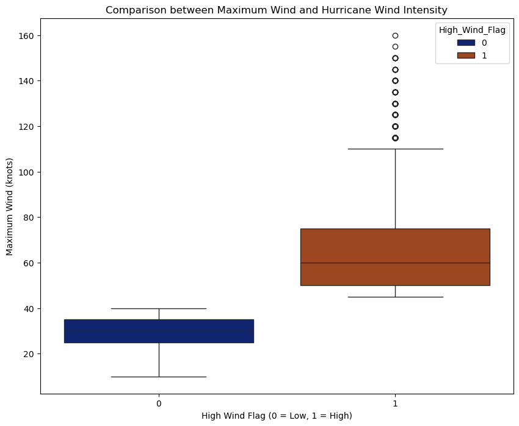

```python
# Boxplot - High_Wind_Flag and Maximum Wind

plt.figure(figsize=(10,8))
sns.boxplot(x='High_Wind_Flag', y='Maximum Wind', data=binarydata, hue='High_Wind_Flag', palette='dark')
plt.title("Comparison between Maximum Wind and Hurricane Wind Intensity")
plt.xlabel("High Wind Flag (0 = Low, 1 = High)")
plt.ylabel("Maximum Wind (knots)")
plt.show()
```

#### Boxplot Interpretation – Comparison between Maximum Wind and High_Wind_Flag

This simplified boxplot is very important because it compares the Maximum Wind between two groups defined by the binary variable High_Wind_Flag, where 0 represents low wind intensity and 1 represents high wind intensity.

The results show that group 1 has much higher average and total wind speeds compared to group 0 with light winds. The average value for storms with high winds is around 60 knots, while for storms with light winds it is closer to 30 knots.

The boxes also show that high wind events vary more, which is expected since severe storms and hurricanes can reach a wider range of maximum wind speeds.

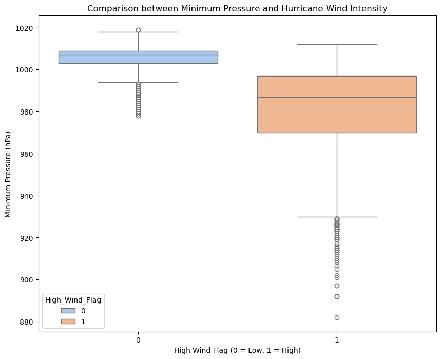

```python
# Boxplot - High_Wind_Flag and Minimum Pressure

plt.figure(figsize=(10,8))
sns.boxplot(x='High_Wind_Flag', y='Minimum Pressure', data=binarydata, hue='High_Wind_Flag', palette='pastel')
plt.title("Comparison between Minimum Pressure and Hurricane Wind Intensity")
plt.xlabel("High Wind Flag (0 = Low, 1 = High)")
plt.ylabel("Minimum Pressure (hPa)")
plt.show()
```

#### Boxplot Interpretation – Comparison between Minimum Pressure and High_Wind_Flag

In this boxplot, we can see an inverse relationship between wind speed and pressure: storms with stronger winds (flag = 1) tend to have much lower central pressure values, while storms with weaker winds (flag = 0) have higher and more stable pressure levels.

Therefore, we can confirm the theory that as wind intensity increases, atmospheric pressure at the center of the storm decreases.

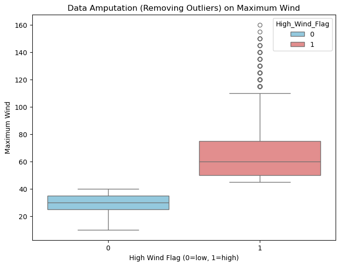

```python
Q1 = binarydata["Maximum Wind"].quantile(0.25)

Q3 = binarydata["Maximum Wind"].quantile(0.75)

IQR = Q3 - Q1

lower_bound= Q1-1.5*IQR

upper_bound= Q3+1.5*IQR

new_cleanData= binarydata[(binarydata["High_Wind_Flag"] >= lower_bound) & (binarydata["High_Wind_Flag"] <= upper_bound)]

plt.figure (figsize = (8,6))
sns.boxplot (x = binarydata ["High_Wind_Flag"], y = binarydata ["Maximum Wind"], hue="High_Wind_Flag", data=new_cleanData, palette=["skyblue", "lightcoral"])
plt.title ("Data Amputation (Removing Outliers) on Maximum Wind")
plt.xlabel ("High Wind Flag (0=low, 1=high)")
plt.ylabel ("Maximum Wind")
plt.show()
```

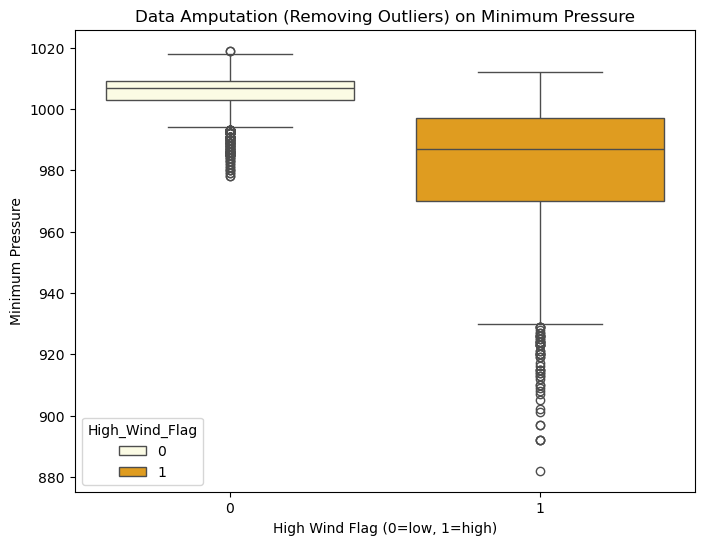

```python
q1 = binarydata["Minimum Pressure"].quantile(0.25)

q3 = binarydata["Minimum Pressure"].quantile(0.75)

iqr = q3 - q1

lowerbound= q1-1.5*iqr

upper_bound= q3+1.5*iqr

new_cleandata= binarydata[(binarydata["High_Wind_Flag"] >= lower_bound) & (binarydata["High_Wind_Flag"] <= upper_bound)]

plt.figure (figsize = (8,6))
sns.boxplot (x = binarydata ["High_Wind_Flag"], y = binarydata ["Minimum Pressure"], hue="High_Wind_Flag", data=new_cleandata, palette=["lightyellow", "orange"])
plt.title ("Data Amputation (Removing Outliers) on Minimum Pressure")
plt.xlabel ("High Wind Flag (0=low, 1=high)")
plt.ylabel ("Minimum Pressure")
plt.show()
```

## Key Insights

- Lower atmospheric pressure is generally associated with higher wind speeds, which aligns with known cyclone dynamics
- The dataset contains significant variability in storm intensity, indicating a wide range of cyclone behaviours
- Certain extreme values highlight the presence of very intense storm events

## Conclusion

This project demonstrates how raw climate data can be transformed into meaningful insights through data analysis techniques.

By applying data cleaning and exploratory analysis, it was possible to identify important relationships between key atmospheric variables.

The project also highlights the importance of combining domain knowledge in meteorology with data analytics skills to better understand extreme weather events.